# Lab8

## Installation

```r
if (!requireNamespace("BiocManager", quietly = TRUE))
    install.packages("BiocManager")

BiocManager::install("ggtree")
```

## Libraries

```r
library(tidyverse)
library(ggtree)
library(treeio)
```

```r
library(ggimage)
```

## Exercise 1

[figure not shown]

NGPhylogeny.fr is a process for phylogenetic analysis by assembling and aligning sequences, determining the relationships between the sequences, and visualizing the relationships between sequences.

```r
# Basic Trees
library(tidyverse)
library(ggtree)

tree <- read.tree("tree_newick.nwk")
tree
```

```
##
## Phylogenetic tree with 13 tips and 12 internal nodes.
##
## Tip labels:
##   A, B, C, D, E, F, ...
##
## Rooted; includes branch lengths.
```

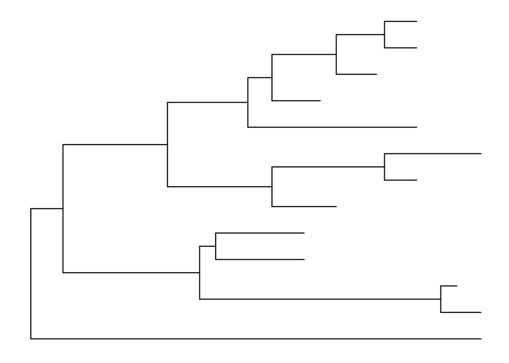

```r
ggplot(tree) + geom_tree() + theme_tree()
```

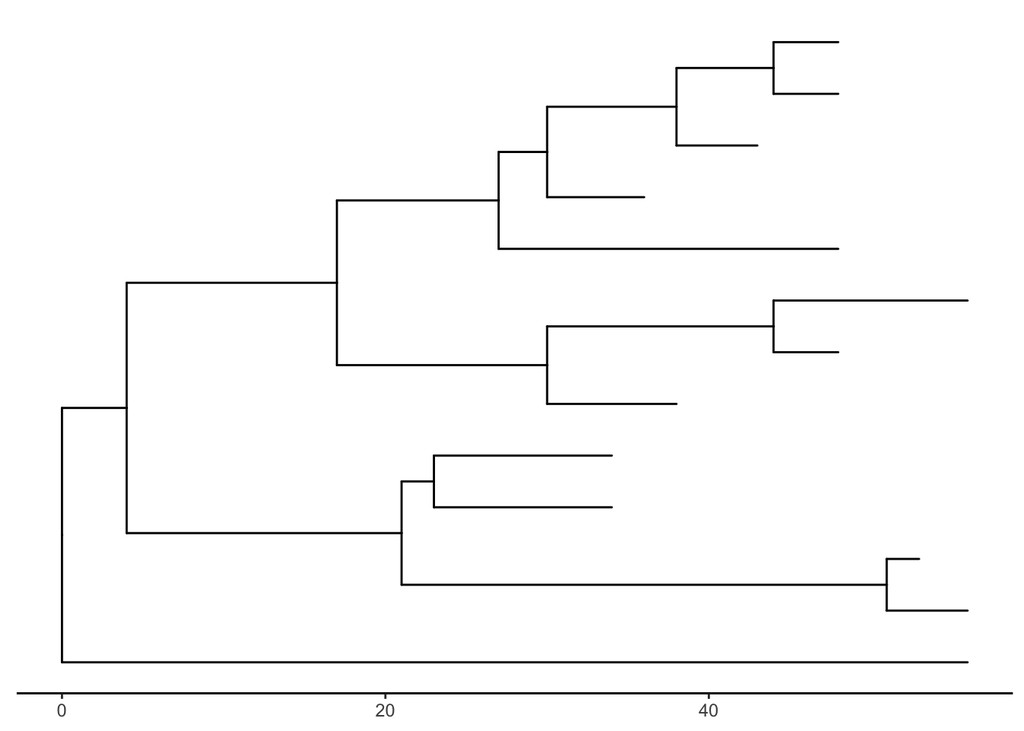

```r
# adding a scale
ggtree(tree) + theme_tree2()
```

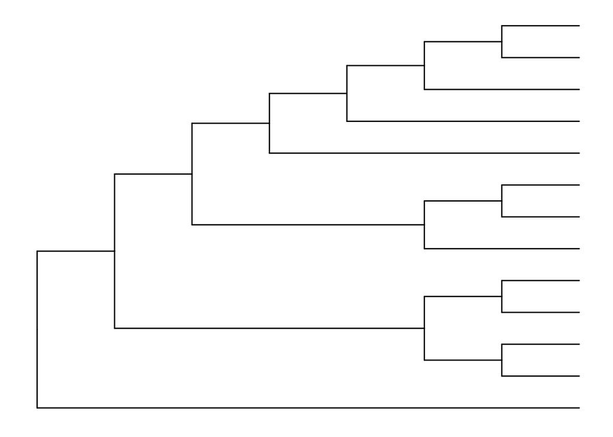

```r
# disable scaling
ggtree(tree, branch.length = "none")
```

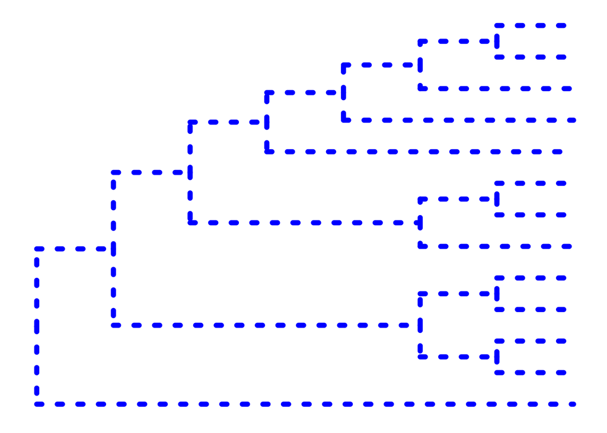

```r
# altering aesthetics
ggtree(tree, branch.length = "none", color = "blue", size = 2, linetype = 3)
```

## Exercise 1

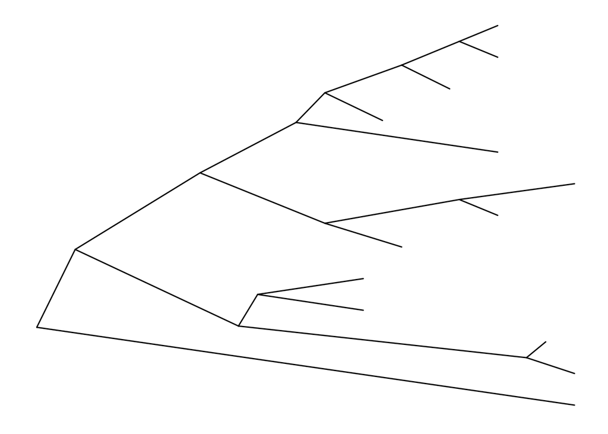

```r
# slanted tree
ggtree(tree, layout = "slanted")
```

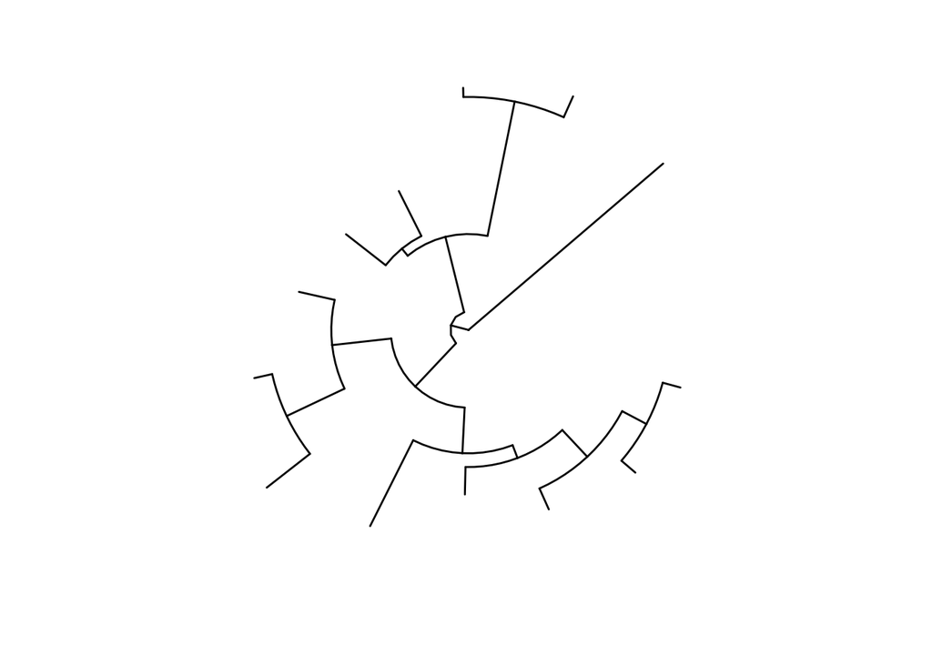

```r
# circular tree
ggtree(tree, layout = "circular")
```

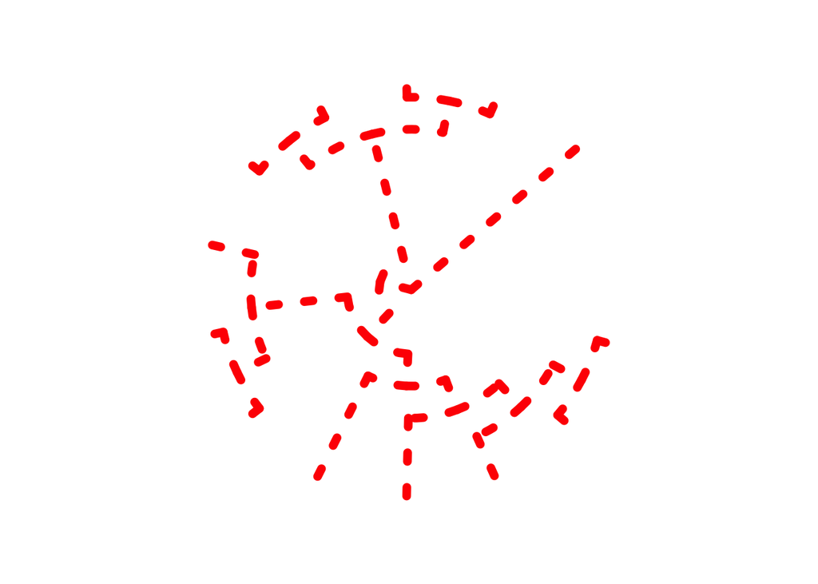

```r
# circular unscaled cladogram with thick red lines
ggtree(tree, layout = "circular", branch.length = "none", color = "red", size = 2.5, linetype = 3)
```

## Other Tree Geoms

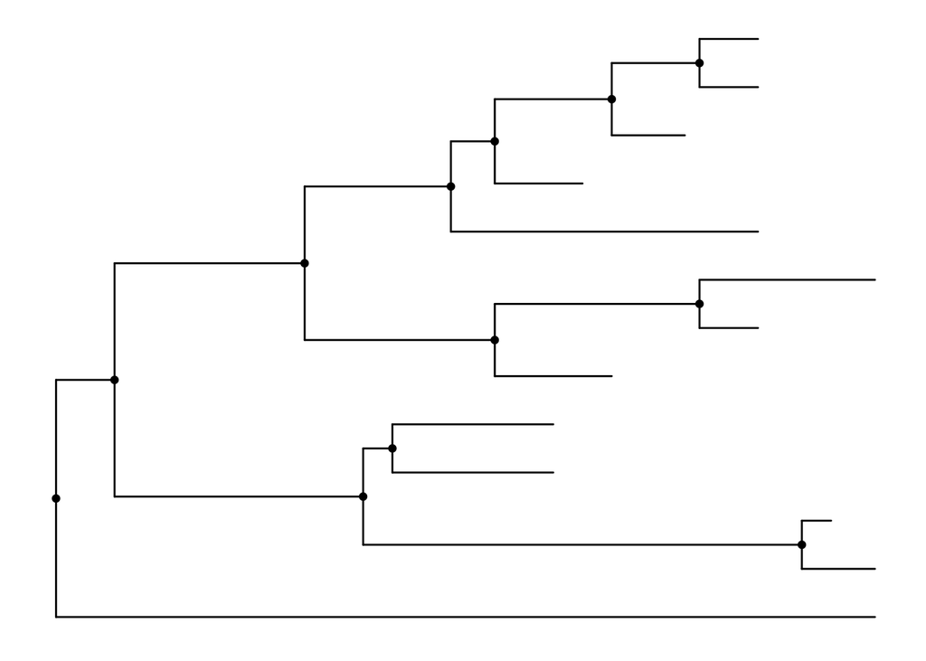

```r
# create the basic plot
p <- ggtree(tree)

# add node points
p + geom_nodepoint()
```

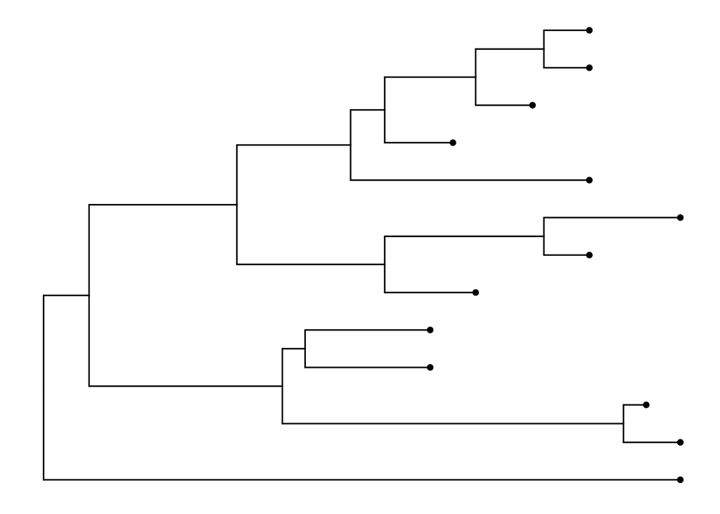

```r
# add tip points
p + geom_tippoint()
```

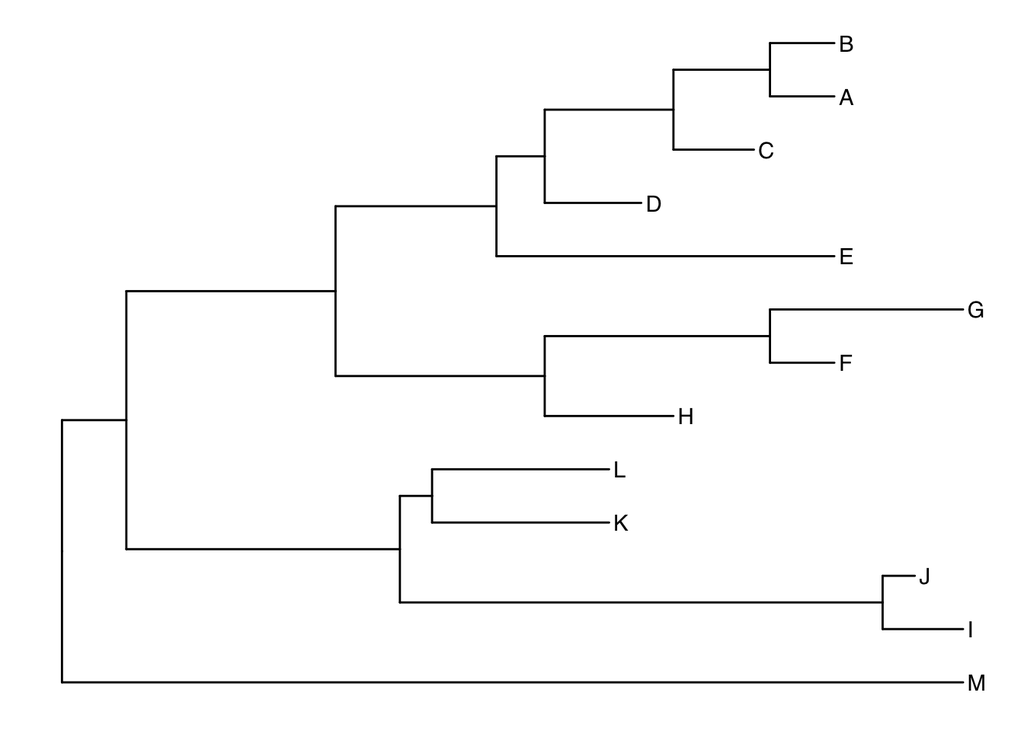

```r
# Label the tips
p + geom_tiplab()
```

## Exercise 2

Create a phylogeny with the following aesthetic characteristics:

–> tips labeled in purple –> purple-colored diamond-shape tip points (hint: Google search “R point characters”) –> large semitransparent yellow node points (hint: alpha=) –> Add a title with `+ ggtitle(…)`

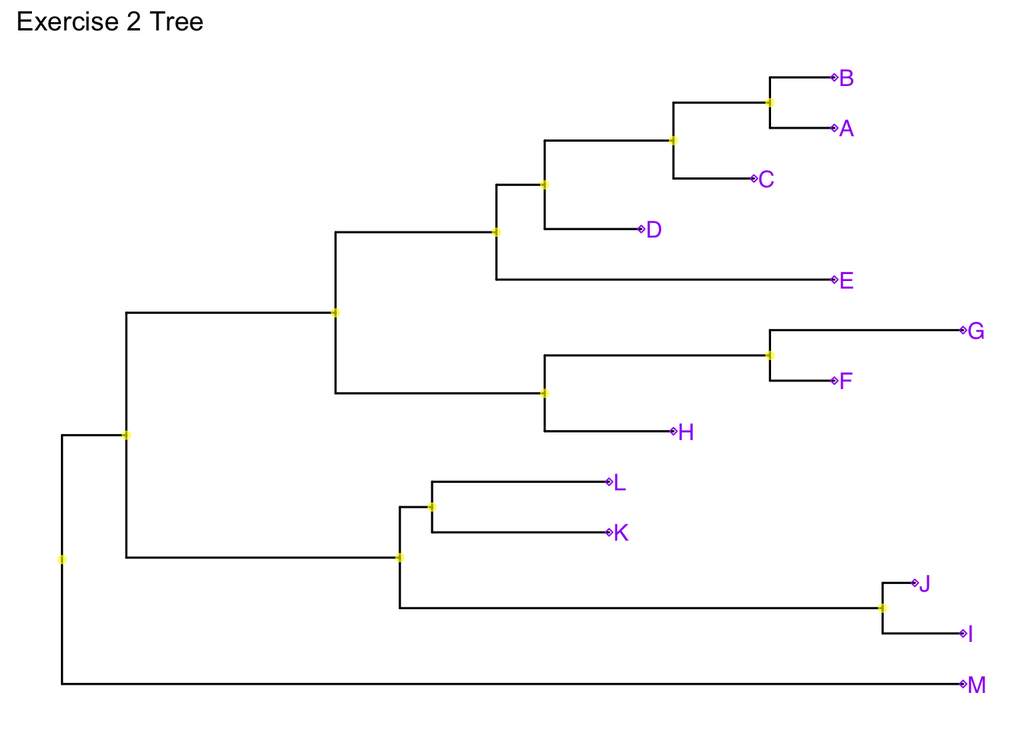

```r
ggtree(tree) +
  geom_tiplab(size = 4, color = "purple") +
  geom_tippoint(size = 1, color = "purple", pch = 23) +
  geom_nodepoint(color = "yellow", alpha = 0.6) +
  ggtitle("Exercise 2 Tree")
```

# Adjusting the internal node number

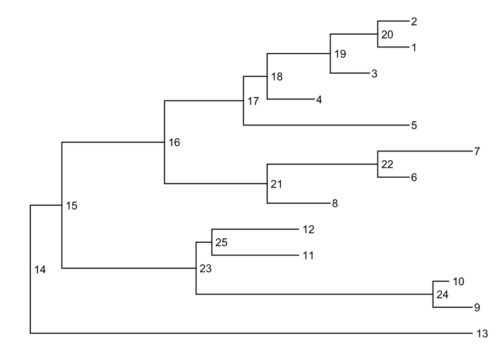

```r
ggtree(tree) +
  geom_text(aes(label = node), hjust = -0.3)
```

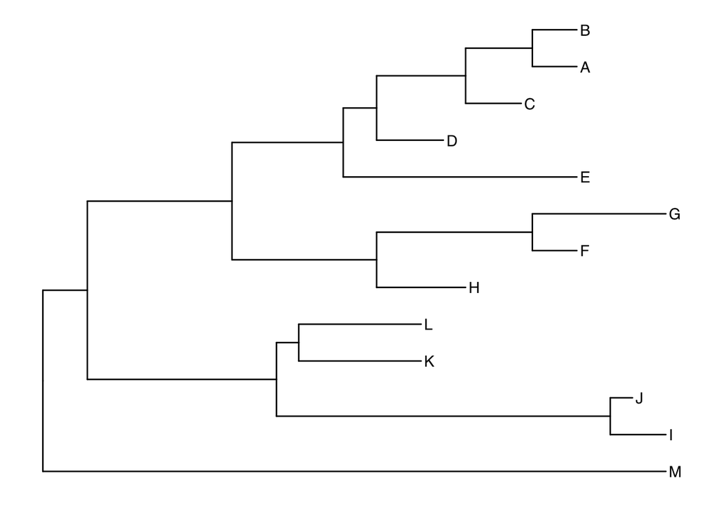

```r
ggtree(tree) +
  geom_tiplab()
```

```r
MRCA(tree, c("C", "E"))
```

```
## [1] 17
```

```r
MRCA(tree, c("G", "H"))
```

```
## [1] 21
```

# Labeling clades

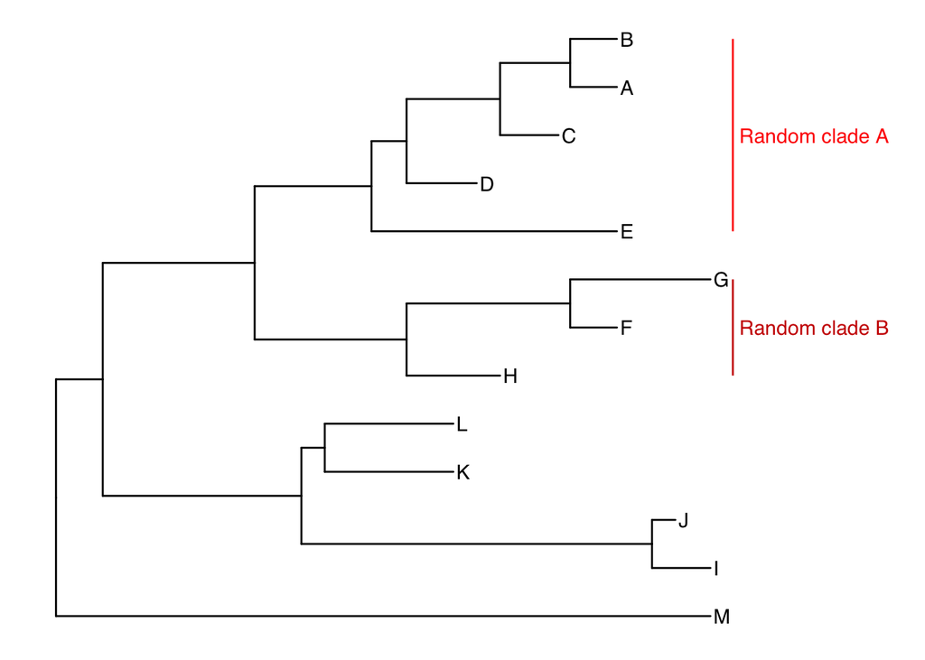

```r
ggtree(tree) +
  geom_tiplab() +
  geom_cladelabel(node = 17, label = "Random clade A", color = "red", offset = 0.8, align = TRUE) +
  geom_cladelabel(node = 21, label = "Random clade B", color = "red3", offset = 0.8, align = TRUE) +
  theme_tree2() +
  xlim(0, 70) +
  theme_tree()
```

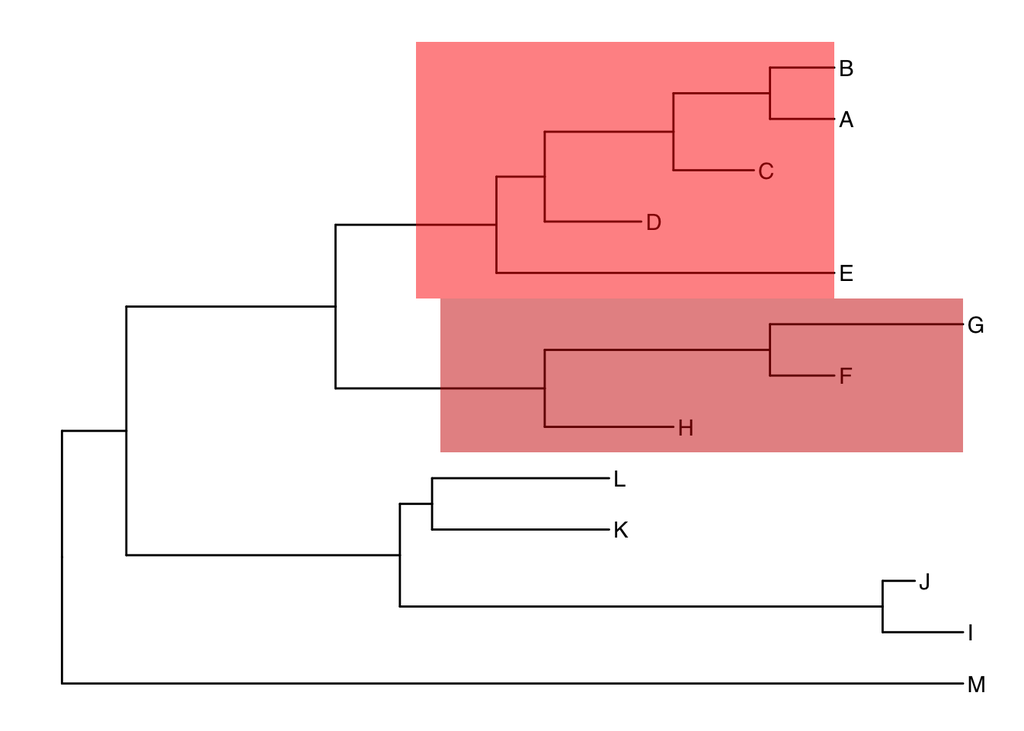

```r
ggtree(tree) +
  geom_tiplab() +
  geom_hilight(node = 17, fill = "red") +
  geom_hilight(node = 21, fill = "red3")
```

# Connecting taxa

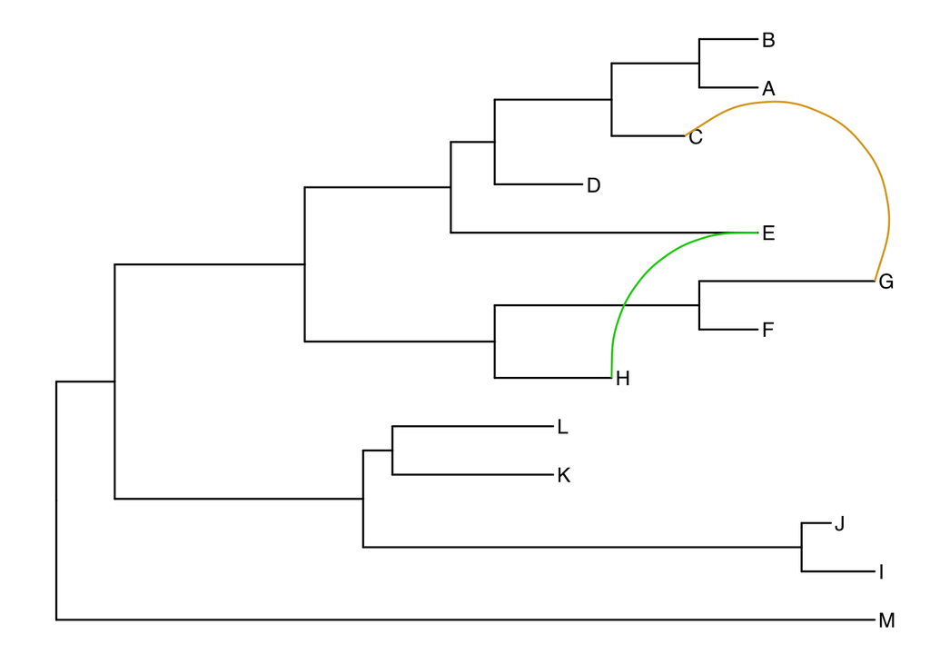

```r
ggtree(tree) +
  geom_tiplab() +
  geom_taxalink("E", "H", color = "green3") +
  geom_taxalink("C", "G", color = "goldenrod", curvature = -0.9)
```

# Exercise 3

```r
MRCA(tree, c("B", "C"))
```

```
## [1] 19
```

```r
MRCA(tree, c("L", "J"))
```

```
## [1] 23
```

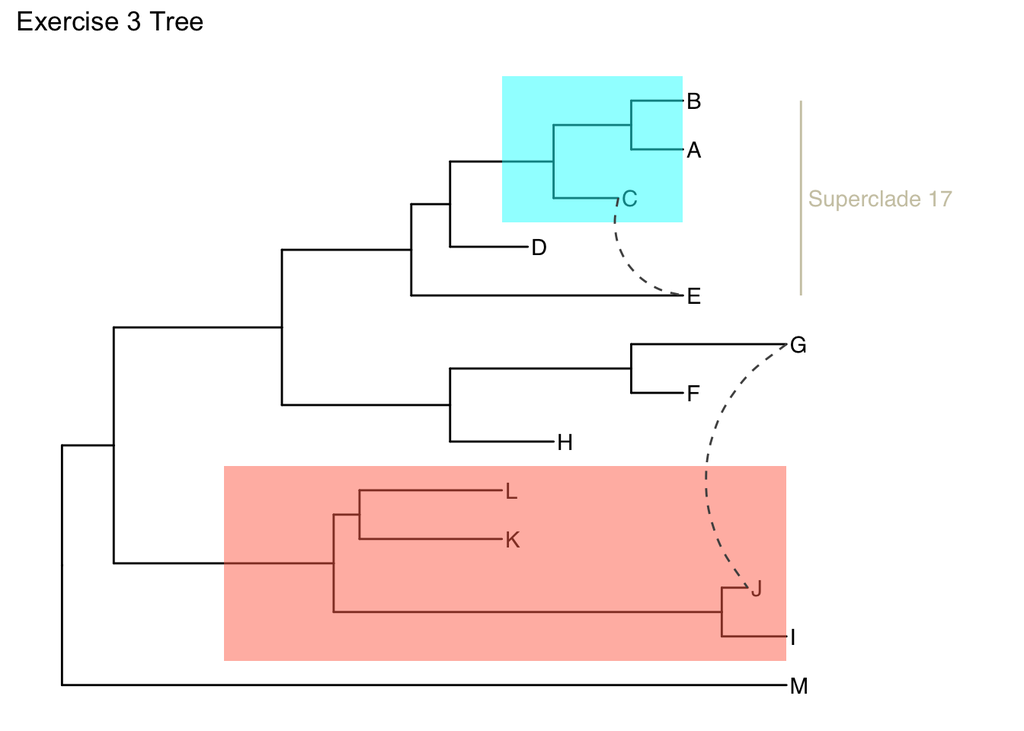

```r
ggtree(tree) +
  geom_tiplab() +
  geom_hilight(node = 19, fill = "cyan") +
  geom_hilight(node = 23, fill = "coral1") +
  geom_cladelabel(node = 17, label = "Superclade 17",
                  color = "cornsilk3", align = TRUE) +
  xlim(0, 70) +
  geom_taxalink("C", "E", color = "gray31", linetype = 2) +
  geom_taxalink("G", "J", color = "gray31", linetype = 2) +
  ggtitle("Exercise 3 Tree")
```

# Advanced tree annotation

# Many trees and plotting tree with other data

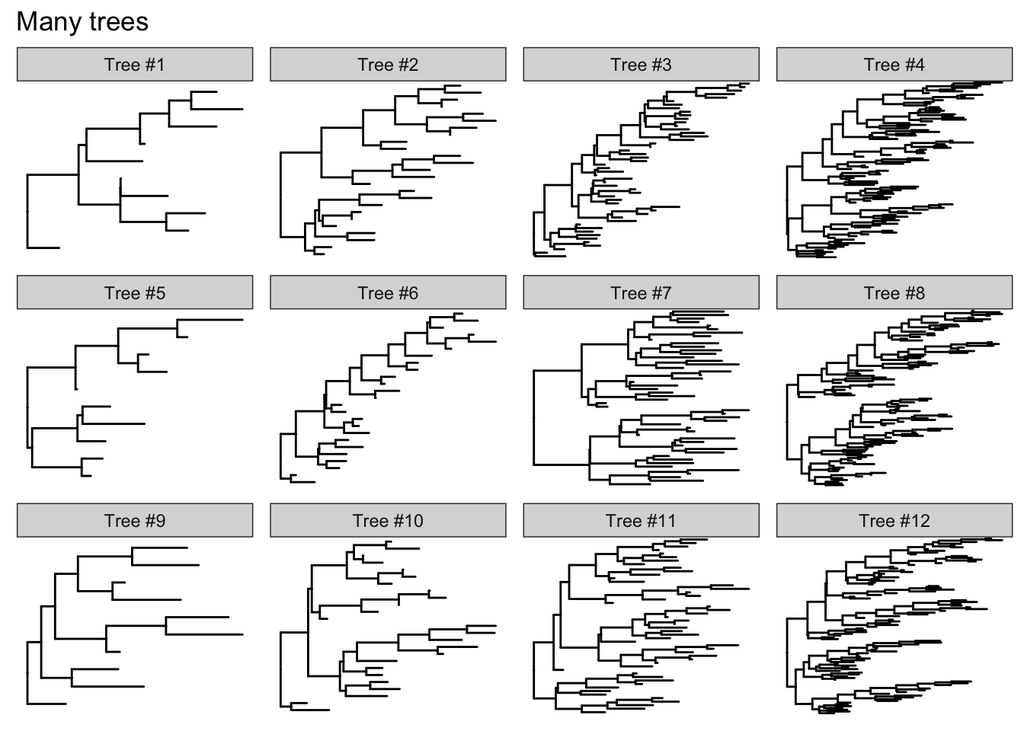

```r
set.seed(42)

trees <- lapply(rep(c(10, 25, 50, 100), 3), rtree)
class(trees) <- "multiPhylo"
ggtree(trees) +
  facet_wrap(~.id, scale = "free", ncol = 4) +
  ggtitle("Many trees")
```

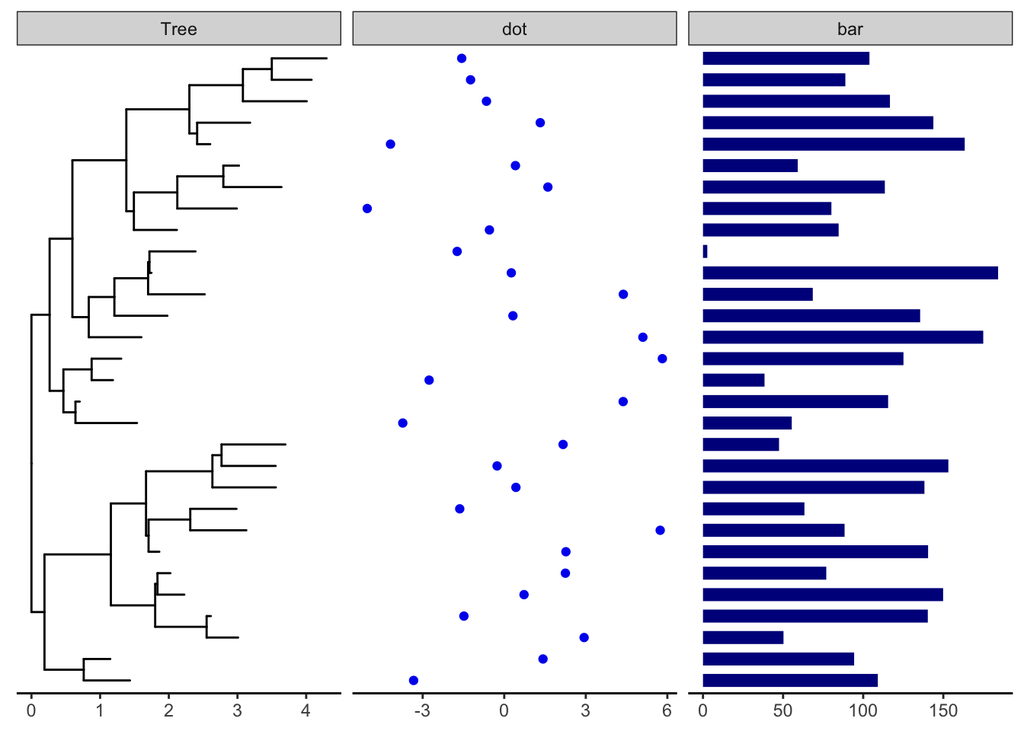

```r
tree <- rtree(30)

p <- ggtree(tree)
d1 <- data.frame(id = tree$tip.label, val = rnorm(30, sd = 3))

p2 <- facet_plot(p, panel = "dot", data=d1, geom=geom_point, aes(x = val), color = 'blue2')

d2 <- data.frame(id = tree$tip.label, value = abs(rnorm(30, mean = 100, sd = 50)))

p3 <- facet_plot(p2, panel = 'bar', data = d2, geom = geom_segment,
           aes(x = 0, xend = value, y = y, yend = y), size = 3, color = 'blue4')

p3 + theme_tree2()
```

# Overlay organism silouhettes

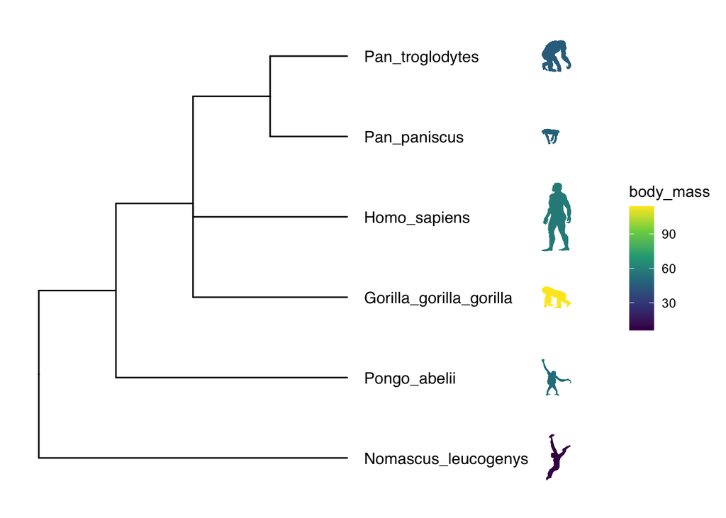

```r
newick <- "((Pongo_abelii,(Gorilla_gorilla_gorilla,(Pan_paniscus,Pan_troglodytes)Pan,Homo_sapiens)Homininae)Hominidae,Nomascus_leucogenys)Hominoidea;"

tree <- read.tree(text=newick)

d <- ggimage::phylopic_uid(tree$tip.label)
d$body_mass = c(52, 114, 47, 45, 58, 6)

p <- ggtree(tree) %<+% d +
  geom_tiplab(aes(image=uid, colour=body_mass), geom="phylopic", offset=2.5) +
  geom_tiplab(aes(label=label), offset = .2) + xlim(NA, 7) +
  scale_color_viridis_c()
p
```

## Exercise 2

Use CIPRES and MAFFT to further organize and align the sequences. Save the tree as fastree_result.tre.

## Exercise 3: ggtree tutorial

First step is to import the tree data. Newick and Nexus file formats are most often compatible with tree viewer software. The ggtree package implements several parser functions including:

- read.tree for reading Newick files
- read.phylip for reading Phylip files
- read.jplace for reading Jplace files
- read.nhx for reading NHX files
- read.beast for parsing output of BEAST
- read.codem1 for parsing output of CODEML
- read.codem_mlc for parsing mlc file
- read.hyphy for parsing output of hyphy
- read.jplace for parsing jplace file including the output from EPA and pplacer
- read.paml_rst for parsing rst file
- read.r8s for parsing output of r8s
- read.raxml for parsing output of RAxML

# Exercise 4

```r
# FastTree <- read.tree("fasttree_results.tre")

# MRCA(FastTree, c("Oryza_mitochondrion", "Thermotoga_lettingae"))
# MRCA(FastTree, c("Thermotoga_lettingae", "Trypanosoma_cruzi"))
# MRCA(FastTree, c("Trypanosoma_cruzi", "Methanocaldococcus_jannaschii"))

# ggtree(FastTree, layout = "circular", branch.length = "none", yscale = "none") +
#  xlim(0,40) +
#  geom_tiplab(hjust = -0.1, size = 3) +
# geom_hilight(node = 34, fill = "orange2", extend = 0.5) +
#  geom_hilight(node = 30, fill = "pink") +
# geom_hilight(node = 25, fill = "cyan2")
```